# Practical Machine Learning Project

Gianni-V

18 octobre 2015

## Synopsis

The purpose of this project is to find a model predicting as precisely as possible the activity quality from activity monitors. The data comes from http://groupware.les.inf.puc-rio.br/har. A random forest model was defined with six influential variables. The model obtains above 98% of correct classifications on the cross-validation set.

## Exploratory data analysis

The data are made of 1 outcome, 159 features and 19622 rows. A simple summary view (in appendix) shows that 2/3 of the features are empty or contain almost NA values thus I focus on the 58 features with data for each row.

```r
library("dplyr")
library("caret")
library("randomForest")
library("doParallel")
library("gridExtra")
set.seed(5345)
```

The following vector contains the feature names that I will use:

```r
colsSel <- c("user_name","raw_timestamp_part_1","raw_timestamp_part_2","new_window","num_window","roll_belt","pitch_belt","yaw_belt","total_accel_belt","gyros_belt_x","gyros_belt_y","gyros_belt_z","accel_belt_x","accel_belt_y","accel_belt_z","magnet_belt_x","magnet_belt_y","magnet_belt_z","roll_arm","pitch_arm","yaw_arm","total_accel_arm","gyros_arm_x","gyros_arm_y","gyros_arm_z","accel_arm_x","accel_arm_y","accel_arm_z","magnet_arm_x","magnet_arm_y","magnet_arm_z","roll_dumbbell","pitch_dumbbell","yaw_dumbbell","total_accel_dumbbell","gyros_dumbbell_x","gyros_dumbbell_y","gyros_dumbbell_z","accel_dumbbell_x","accel_dumbbell_y","accel_dumbbell_z","magnet_dumbbell_x","magnet_dumbbell_y","magnet_dumbbell_z","roll_forearm","pitch_forearm","yaw_forearm","total_accel_forearm","gyros_forearm_x","gyros_forearm_y","gyros_forearm_z","accel_forearm_x","accel_forearm_y","accel_forearm_z","magnet_forearm_x","magnet_forearm_y","magnet_forearm_z", "classe")
```

Before anything else, the training set is split into a sampled training set of 2000 rows and a cross-validation set with the 17622 remaining rows.

```r
origTraining <- read.csv("pml-training.csv")
training <- select_(origTraining, .dots = colsSel)

samp <- sample(nrow(training), 2000)
trainSet <- training[samp,]
cvSet <- training[-samp,]
```

First of all, I try to fit a random forest on all the features. The partitioning process of tree classification seems right to manage that data set of which the features seem intermingled and the random forest will avoid overfitting.

After that step, my intention is to find the most important varables and restrict the final model to those ones. By the way, I use a parallel implementation of random forest that run quicker on multicores computers.

```r
registerDoParallel()
fitRF <- train(classe ~ ., data = trainSet, method = "parRF", prox=T)
```

The important variables can be obtained with the **importance** function. It gives the mean decrease in Gini index on a per variable basis, ie an increase in homogeneity/purity.

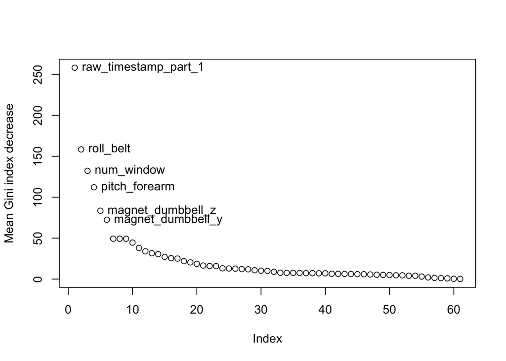

```r
imp <- importance(fitRF$finalModel)
imp <- data.frame(colnames = rownames(imp), imp) %>% arrange(desc(MeanDecreaseGini))
plot(imp$MeanDecreaseGini, ylab = "Mean Gini index decrease")
text(imp[1:6,]$MeanDecreaseGini, labels = imp[1:6,]$colnames, pos = 4)
```

The 6 most influential features are:

```r
for(c in imp[1:6,]$colnames) print(c)
```

```
## [1] "raw_timestamp_part_1"
## [1] "roll_belt"
## [1] "num_window"
## [1] "pitch_forearm"
## [1] "magnet_dumbbell_z"
## [1] "magnet_dumbbell_y"
```

## Final model

The final model is fitted with those 6 features.

```r
reducFormula <- as.formula(paste("classe", " ~ ", "`", paste(imp[1:6,]$colnames, collapse="` + `"), "`", sep=""))
fitRF <- train(reducFormula, data = trainSet, method = "parRF", prox=T)
```

Finally, it is cross-validated with the cross-validation set:

```r
pred <- predict(fitRF, cvSet)
```

Tha accuracy is computed with a contingency table:

```r
tab <- table(pred, cvSet$classe)
percentOK <- sum(diag(tab))/sum(tab) * 100
```

The accuracy for that model is **98.73%**.

## Inside the black box

The job is done, but by curiosity, now that we have come to only 6 features, we can plot them and see a bit more clearly the structure in the data set.

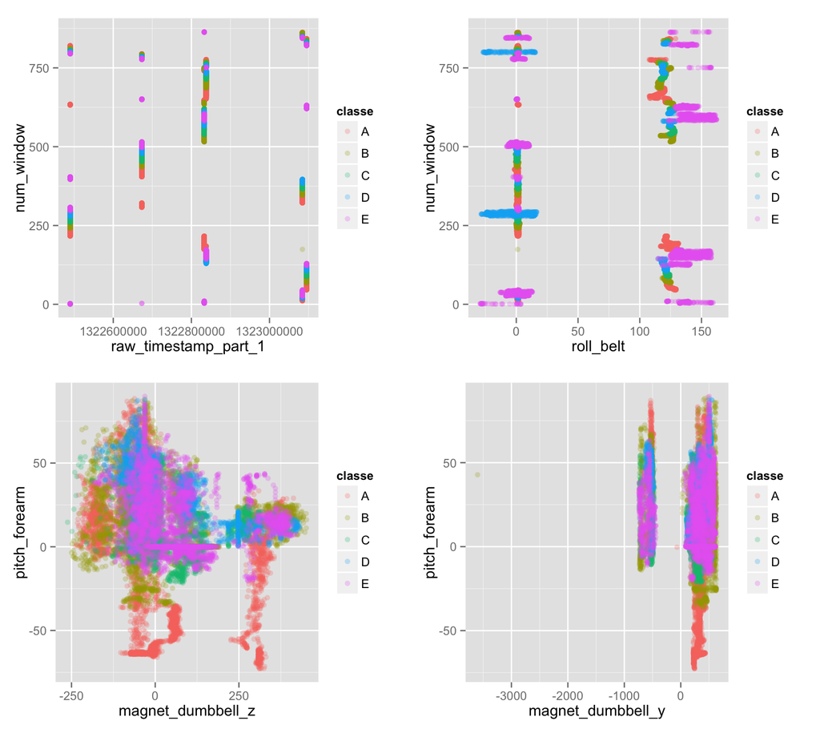

```r
gPts <- geom_point(position = "jitter", alpha = .25)

feat1_3 <- ggplot(data = training, aes_string(x = as.character(imp$colnames[1]), y = as.character(imp$colnames[3]), col = "classe")) + gPts
feat2_3 <- ggplot(data = training, aes_string(x = as.character(imp$colnames[2]), y = as.character(imp$colnames[3]), col = "classe")) + gPts
feat5_4 <- ggplot(data = training, aes_string(x = as.character(imp$colnames[5]), y = as.character(imp$colnames[4]), col = "classe")) + gPts
feat6_4 <- ggplot(data = training, aes_string(x = as.character(imp$colnames[6]), y = as.character(imp$colnames[4]), col = "classe")) + gPts

grid.arrange(feat1_3, feat2_3, feat5_4, feat6_4, nrow = 2, ncol = 2)
```

Obviously, those 6 features succeed quite nicely in displaying patches of homogeneous classes.

## Appendix

### Summary of original training data:

```r
summary(origTraining)
```

```
##        X            user_name    raw_timestamp_part_1 raw_timestamp_part_2
##  Min.   :    1   adelmo  :3892   Min.   :1322489605   Min.   :   294
##  1st Qu.: 4906   carlitos:3112   1st Qu.:1322673099   1st Qu.:252912
##  Median : 9812   charles :3536   Median :1322832920   Median :496380
##  Mean   : 9812   eurico  :3070   Mean   :1322827119   Mean   :500656
##  3rd Qu.:14717   jeremy  :3402   3rd Qu.:1323084264   3rd Qu.:751891
##  Max.   :19622   pedro   :2610   Max.   :1323095081   Max.   :998801
##
##           cvtd_timestamp  new_window    num_window    roll_belt
##  28/11/2011 14:14: 1498   no :19216   Min.   :  1   Min.   :-29
##  05/12/2011 11:24: 1497   yes:  406   1st Qu.:222   1st Qu.:  1
##  30/11/2011 17:11: 1440               Median :424   Median :113
##  05/12/2011 11:25: 1425               Mean   :431   Mean   : 64
##  02/12/2011 14:57: 1380               3rd Qu.:644   3rd Qu.:123
##  02/12/2011 13:34: 1375               Max.   :864   Max.   :162
##  (Other)         :11007
##    pitch_belt     yaw_belt    total_accel_belt kurtosis_roll_belt
##  Min.   :-56   Min.   :-180   Min.   : 0.0              :19216
##  1st Qu.:  2   1st Qu.: -88   1st Qu.: 3.0     #DIV/0!  :   10
##  Median :  5   Median : -13   Median :17.0     -1.908453:    2
##  Mean   :  0   Mean   : -11   Mean   :11.3     -0.016850:    1
##  3rd Qu.: 15   3rd Qu.:  13   3rd Qu.:18.0     -0.021024:    1
##  Max.   : 60   Max.   : 179   Max.   :29.0     -0.025513:    1
##                                                (Other)  :  391
##  kurtosis_picth_belt kurtosis_yaw_belt skewness_roll_belt
##           :19216            :19216              :19216
##  #DIV/0!  :   32     #DIV/0!:  406     #DIV/0!  :    9
##  47.000000:    4                       0.000000 :    4
##  -0.150950:    3                       0.422463 :    2
##  -0.684748:    3                       -0.003095:    1
##  -1.750749:    3                       -0.010002:    1
##  (Other)  :  361                       (Other)  :  389
##  skewness_roll_belt.1 skewness_yaw_belt max_roll_belt   max_picth_belt
##           :19216             :19216     Min.   :-94     Min.   : 3
##  #DIV/0!  :   32      #DIV/0!:  406     1st Qu.:-88     1st Qu.: 5
##  0.000000 :    4                        Median : -5     Median :18
##  -2.156553:    3                        Mean   : -7     Mean   :13
##  -3.072669:    3                        3rd Qu.: 18     3rd Qu.:19
##  -6.324555:    3                        Max.   :180     Max.   :30
##  (Other)  :  361                        NA's   :19216   NA's   :19216
```

[output cut: 289 more lines]

```
##  Min.   :-498    Min.   :-632    Min.   :-446    Min.   :-1280
##  1st Qu.:-178    1st Qu.:  57    1st Qu.:-182    1st Qu.: -616
##  Median : -57    Median : 201    Median : -39    Median : -378
##  Mean   : -62    Mean   : 164    Mean   : -55    Mean   : -313
##  3rd Qu.:  76    3rd Qu.: 312    3rd Qu.:  26    3rd Qu.:  -73
##  Max.   : 477    Max.   : 923    Max.   : 291    Max.   :  672
##
##  magnet_forearm_y magnet_forearm_z classe
##  Min.   :-896     Min.   :-973     A:5580
##  1st Qu.:   2     1st Qu.: 191     B:3797
##  Median : 591     Median : 511     C:3422
##  Mean   : 380     Mean   : 394     D:3216
##  3rd Qu.: 737     3rd Qu.: 653     E:3607
##  Max.   :1480     Max.   :1090
##
```